# Relationship Between Ozone & Temperature

Tianhai Zu

2020-10-18

## Data

The `atmos` data set resides in the `nasaweather` package of the *R* programming language. It contains a collection of atmospheric variables measured between 1995 and 2000 on a grid of 576 coordinates in the western hemisphere. The data set comes from the [2006 ASA Data Expo](http://stat-computing.org/dataexpo/2006/).

Some of the variables in the `atmos` data set are:

- **temp** - The mean monthly air temperature near the surface of the Earth (measured in degrees kelvin (*K*))
- **pressure** - The mean monthly air pressure at the surface of the Earth (measured in millibars (*mb*))
- **ozone** - The mean monthly abundance of atmospheric ozone (measured in Dobson units (*DU*))

You can convert the temperature unit from Kelvin to Celsius with the formula

$$celsius = kelvin - 273.15$$

And you can convert the result to Fahrenheit with the formula

$$fahrenheit = celsius \times \frac{9}{5} + 32$$

## Cleaning

To analyze this data, we will use the following R packages:

```r
library(nasaweather)
library(magrittr)
library(tidyverse)
```

```r
means <- atmos %>%
  filter(year == year) %>%
  group_by(long, lat) %>%
  summarize(temp = mean(temp, na.rm = TRUE),
            pressure = mean(pressure, na.rm = TRUE),
            ozone = mean(ozone, na.rm = TRUE),
            cloudlow = mean(cloudlow, na.rm = TRUE),
            cloudmid = mean(cloudmid, na.rm = TRUE),
            cloudhigh = mean(cloudhigh, na.rm = TRUE)) %>%
  ungroup()
```

where the `year` object equals 2000.

## Ozone and temperature

Is the relationship between ozone and temperature useful for understanding fluctuations in ozone? A scatterplot of the variables shows a strong, but unusual relationship.

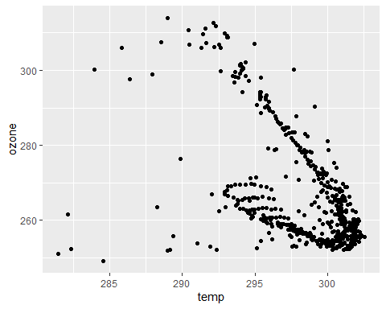

We suspect that group level effects are caused by environmental conditions that vary by locale. To test this idea, we sort each data point into one of four geographic regions:

```r
means$locale <- "north america"
means$locale[means$lat < 10] <- "south pacific"
means$locale[means$long > -80 & means$lat < 10] <- "south america"
means$locale[means$long > -80 & means$lat > 10] <- "north atlantic"
```

### Model

We suggest that ozone is highly correlated with temperature, but that a different relationship exists for each geographic region. We capture this relationship with a second order linear model of the form

$$ozone = \alpha + \beta_{1} temperature + \sum_{locales} \beta_{i} locale_{i} + \sum_{locales} \beta_{j} interaction_{j} + \epsilon$$

This yields the following coefficients and relationships.

```r
lm(ozone ~ temp + locale + temp:locale, data = means)
```

```
Call:
lm(formula = ozone ~ temp + locale + temp:locale, data = means)

Coefficients:
              (Intercept)                       temp       localenorth atlantic        localesouth america
                 1336.508                     -3.559                    548.248                  -1061.452
      localesouth pacific  temp:localenorth atlantic   temp:localesouth america   temp:localesouth pacific
                 -549.906                     -1.827                      3.496                      1.785
```

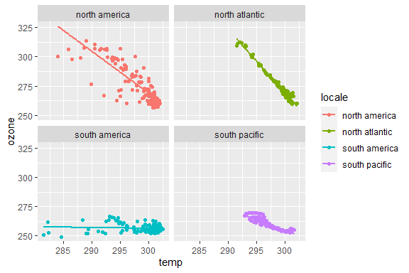

### Diagnostics

An anova test suggests that both locale and the interaction effect of locale and temperature are useful for predicting ozone (i.e., the p-value that compares the full model to the reduced models is statistically significant).

```r
mod <- lm(ozone ~ temp, data = means)
mod2 <- lm(ozone ~ temp + locale, data = means)
mod3 <- lm(ozone ~ temp + locale + temp:locale, data = means)

anova(mod, mod2, mod3)
```

```
Analysis of Variance Table

Model 1: ozone ~ temp
Model 2: ozone ~ temp + locale
Model 3: ozone ~ temp + locale + temp:locale
  Res.Df   RSS Df Sum of Sq      F    Pr(>F)
1    574 99335
2    571 41425  3     57911 706.17 < 2.2e-16 ***
3    568 15527  3     25898 315.81 < 2.2e-16 ***
---
Signif. codes:  0 ‘***’ 0.001 ‘**’ 0.01 ‘*’ 0.05 ‘.’ 0.1 ‘ ’ 1
```